# Kings County Housing Prices Bakeoff

Below are a list of steps that you should take while trying to complete your bake-off entry.

## Step 1: Read in Data, Correlation Coefficients, Data Visualizations

```python
import pandas as pd
import matplotlib.pyplot as plt
import numpy as np
import seaborn as sns
```

```python
df = pd.read_csv('data_files/kc_house_data_train.csv', index_col=0)
```

```python
pd.set_option('display.max_columns', None)
```

```python
df['date_formatted'] = pd.to_datetime(df['date'])
```

```python
# clean up the house with 33 bedrooms, set it equal to 3
df['bedrooms'] = df['bedrooms'].replace({33:3})
df['bedrooms'].value_counts()
```

```
3     7865
4     5488
2     2204
5     1283
6      229
1      160
7       30
0       12
8       10
9        5
10       3
11       1
Name: bedrooms, dtype: int64
```

```python
import pandas as pd
pd.set_option('display.max_columns', 300)
pd.set_option('display.max_rows', 200)

import numpy as np
from matplotlib import pyplot as plt
from sklearn import linear_model
from sklearn.linear_model import LinearRegression
from sklearn.model_selection import train_test_split
from sklearn import metrics
from sklearn.preprocessing import PolynomialFeatures
from sklearn.preprocessing import StandardScaler
import seaborn as sns
sns.set(style="whitegrid")
```

```python
df.columns
```

```
Index(['id', 'date', 'price', 'bedrooms', 'bathrooms', 'sqft_living',
       'sqft_lot', 'floors', 'waterfront', 'view', 'condition', 'grade',
       'sqft_above', 'sqft_basement', 'yr_built', 'yr_renovated', 'zipcode',
       'lat', 'long', 'sqft_living15', 'sqft_lot15', 'date_formatted'],
      dtype='object')
```

```python
# set up features and target
features=['bedrooms', 'bathrooms', 'sqft_living',  # excl id and 'date',
       'sqft_lot', 'floors', 'waterfront', 'view', 'condition', 'grade',
       'sqft_above', 'sqft_basement', 'yr_built', 'yr_renovated', 'zipcode',
       'lat', 'long', 'sqft_living15', 'sqft_lot15'] # 'date_formatted'

df_features = df[features]

target = df['price']
```

## Correlation coefficients

```python
X_train_8, X_test_8, y_train_8, y_test_8 = train_test_split(df_features, target, random_state=9,test_size=0.2)
```

```python
# Create correlation matrix
corr_matrix = X_train_8.corr().abs()

# Select upper triangle of correlation matrix
upper = corr_matrix.where(np.triu(np.ones(corr_matrix.shape), k=1).astype(np.bool))
upper
```

|  | bedrooms | bathrooms | sqft_living | sqft_lot | floors | waterfront | view | condition | grade | sqft_above | sqft_basement | yr_built | yr_renovated | zipcode | lat | long | sqft_living15 | sqft_lot15 |
| --- | --- | --- | --- | --- | --- | --- | --- | --- | --- | --- | --- | --- | --- | --- | --- | --- | --- | --- |
| bedrooms | NaN | 0.525995 | 0.586839 | 0.030560 | 0.179315 | 0.007167 | 0.078216 | 0.016175 | 0.363436 | 0.487800 | 0.306275 | 0.164581 | 0.012288 | 0.146273 | 0.007597 | 0.120493 | 0.398813 | 0.019807 |
| bathrooms | NaN | NaN | 0.754353 | 0.078504 | 0.492800 | 0.072574 | 0.188267 | 0.123807 | 0.664316 | 0.684122 | 0.288169 | 0.507678 | 0.051492 | 0.193006 | 0.021930 | 0.215522 | 0.565778 | 0.074053 |
| sqft_living | NaN | NaN | NaN | 0.168833 | 0.351500 | 0.121827 | 0.285025 | 0.062317 | 0.760049 | 0.874431 | 0.442037 | 0.316571 | 0.052999 | 0.187331 | 0.051552 | 0.228677 | 0.751843 | 0.170894 |
| sqft_lot | NaN | NaN | NaN | NaN | 0.004269 | 0.016966 | 0.077697 | 0.010798 | 0.116790 | 0.181008 | 0.012922 | 0.054997 | 0.005931 | 0.126555 | 0.088823 | 0.219890 | 0.148123 | 0.730340 |
| floors | NaN | NaN | NaN | NaN | NaN | 0.026498 | 0.025216 | 0.257399 | 0.456882 | 0.526344 | 0.249500 | 0.481202 | 0.008334 | 0.058942 | 0.045221 | 0.124712 | 0.277224 | 0.010396 |
| waterfront | NaN | NaN | NaN | NaN | NaN | NaN | 0.418471 | 0.006766 | 0.096860 | 0.083276 | 0.096845 | 0.020006 | 0.094712 | 0.033314 | 0.006153 | 0.039215 | 0.098347 | 0.024004 |
| view | NaN | NaN | NaN | NaN | NaN | NaN | NaN | 0.040953 | 0.251795 | 0.164209 | 0.283196 | 0.046915 | 0.092113 | 0.090405 | 0.008581 | 0.073212 | 0.283037 | 0.069932 |
| condition | NaN | NaN | NaN | NaN | NaN | NaN | NaN | NaN | 0.145388 | 0.157424 | 0.162766 | 0.363959 | 0.060430 | 0.005186 | 0.013361 | 0.109302 | 0.093753 | 0.011136 |
| grade | NaN | NaN | NaN | NaN | NaN | NaN | NaN | NaN | NaN | 0.755676 | 0.167599 | 0.448011 | 0.011643 | 0.179040 | 0.116612 | 0.191478 | 0.713230 | 0.114429 |
| sqft_above | NaN | NaN | NaN | NaN | NaN | NaN | NaN | NaN | NaN | NaN | 0.048646 | 0.420815 | 0.025760 | 0.255650 | 0.002408 | 0.334193 | 0.728536 | 0.186486 |
| sqft_basement | NaN | NaN | NaN | NaN | NaN | NaN | NaN | NaN | NaN | NaN | NaN | 0.126299 | 0.061486 | 0.086999 | 0.110586 | 0.147097 | 0.200885 | 0.007038 |
| yr_built | NaN | NaN | NaN | NaN | NaN | NaN | NaN | NaN | NaN | NaN | NaN | NaN | 0.223100 | 0.344569 | 0.145054 | 0.407579 | 0.327004 | 0.072863 |
| yr_renovated | NaN | NaN | NaN | NaN | NaN | NaN | NaN | NaN | NaN | NaN | NaN | NaN | NaN | 0.061473 | 0.025180 | 0.058475 | 0.006539 | 0.005796 |
| zipcode | NaN | NaN | NaN | NaN | NaN | NaN | NaN | NaN | NaN | NaN | NaN | NaN | NaN | NaN | 0.269612 | 0.563099 | 0.271107 | 0.146793 |
| lat | NaN | NaN | NaN | NaN | NaN | NaN | NaN | NaN | NaN | NaN | NaN | NaN | NaN | NaN | NaN | 0.135534 | 0.052931 | 0.089690 |
| long | NaN | NaN | NaN | NaN | NaN | NaN | NaN | NaN | NaN | NaN | NaN | NaN | NaN | NaN | NaN | NaN | 0.323030 | 0.255566 |
| sqft_living15 | NaN | NaN | NaN | NaN | NaN | NaN | NaN | NaN | NaN | NaN | NaN | NaN | NaN | NaN | NaN | NaN | NaN | 0.181796 |
| sqft_lot15 | NaN | NaN | NaN | NaN | NaN | NaN | NaN | NaN | NaN | NaN | NaN | NaN | NaN | NaN | NaN | NaN | NaN | NaN |

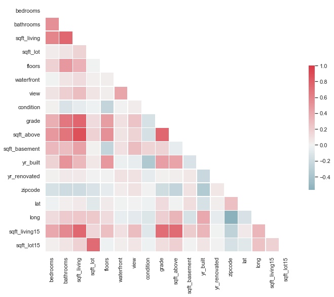

```python
sns.set(style="white")

# Compute the correlation matrix
corr = X_train_8.corr()

# Generate a mask for the upper triangle
mask = np.zeros_like(corr, dtype=np.bool)
mask[np.triu_indices_from(mask)] = True

# Set up the matplotlib figure
f, ax = plt.subplots(figsize=(11, 9))

# Generate a custom diverging colormap
cmap = sns.diverging_palette(220, 10, as_cmap=True)

# Draw the heatmap with the mask and correct aspect ratio
sns.heatmap(corr, mask=mask, cmap=cmap, vmax=1, center=0,
            square=True, linewidths=.5, cbar_kws={"shrink": .5})
```

```python
# Find index of feature columns with correlation greater than 0.80
to_drop = [column for column in upper.columns if any(upper[column] > 0.80)]

#if you change inplace to True it will go through and drop all of those columns from the dataset
X_train_8.drop(columns=to_drop, inplace=False)
X_test_8.drop(columns=to_drop, inplace=False)
```

|  | bedrooms | bathrooms | sqft_living | sqft_lot | floors | waterfront | view | condition | grade | sqft_basement | yr_built | yr_renovated | zipcode | lat | long | sqft_living15 | sqft_lot15 |
| --- | --- | --- | --- | --- | --- | --- | --- | --- | --- | --- | --- | --- | --- | --- | --- | --- | --- |
| 13347 | 4 | 2.75 | 1610 | 11201 | 1.0 | 0 | 0 | 5 | 7 | 590 | 1982 | 0 | 98033 | 47.7024 | -122.198 | 1610 | 9000 |
| 12171 | 3 | 2.00 | 1610 | 13309 | 1.0 | 0 | 0 | 4 | 7 | 0 | 1967 | 0 | 98042 | 47.3398 | -122.133 | 1610 | 15725 |
| 5900 | 3 | 1.75 | 1900 | 5520 | 1.0 | 0 | 0 | 3 | 7 | 620 | 1982 | 0 | 98118 | 47.5549 | -122.292 | 1330 | 5196 |
| 7160 | 4 | 3.50 | 2690 | 5564 | 2.0 | 0 | 0 | 3 | 7 | 0 | 2007 | 0 | 98038 | 47.3537 | -122.018 | 2210 | 4046 |
| 13494 | 3 | 1.75 | 1170 | 8740 | 1.0 | 0 | 0 | 4 | 7 | 0 | 1968 | 0 | 98052 | 47.6849 | -122.117 | 1870 | 8448 |
| ... | ... | ... | ... | ... | ... | ... | ... | ... | ... | ... | ... | ... | ... | ... | ... | ... | ... |
| 4742 | 4 | 2.25 | 1900 | 10950 | 1.0 | 0 | 0 | 4 | 7 | 500 | 1959 | 0 | 98032 | 47.3582 | -122.284 | 1700 | 11850 |
| 11094 | 4 | 2.50 | 1870 | 8190 | 1.0 | 0 | 0 | 3 | 7 | 770 | 1977 | 0 | 98058 | 47.4521 | -122.161 | 1590 | 9150 |
| 5004 | 4 | 2.25 | 2320 | 8760 | 1.0 | 0 | 0 | 4 | 8 | 1160 | 1966 | 0 | 98032 | 47.3627 | -122.285 | 1970 | 8690 |
| 5925 | 3 | 3.25 | 1530 | 1786 | 2.0 | 0 | 0 | 3 | 8 | 330 | 2007 | 0 | 98117 | 47.6783 | -122.366 | 1390 | 2900 |
| 9211 | 3 | 2.50 | 1710 | 4920 | 2.0 | 0 | 0 | 3 | 7 | 0 | 1990 | 0 | 98126 | 47.5347 | -122.376 | 1500 | 4920 |

3458 rows × 17 columns

```python
to_drop
# Result: ['sqft_above'] is correlated with 'sqft_living'
# Additional notes:
# ['sqft_living', 'grade', 'sqft_above', 'sqft_living15', 'sqft_lot15'] to drop if .70 threshold is used
# ['sqft_living', 'grade', 'sqft_above', 'sqft_living15'] to drop if .75 threshold is used
```

```
['sqft_above']
```

## Variance Inflation Factor (VIF)

```python
from statsmodels.stats.outliers_influence import variance_inflation_factor
```

```python
vif = pd.DataFrame()
vif["VIF Factor"] = [variance_inflation_factor(df_features.values, i) for i in range(df_features.shape[1])]
vif["features"] = df_features.columns
vif.round(1)
```

|  | VIF Factor | features |
| --- | --- | --- |
| 0 | 24.7 | bedrooms |
| 1 | 28.5 | bathrooms |
| 2 | inf | sqft_living |
| 3 | 2.3 | sqft_lot |
| 4 | 16.8 | floors |
| 5 | 1.2 | waterfront |
| 6 | 1.6 | view |
| 7 | 34.5 | condition |
| 8 | 148.2 | grade |
| 9 | inf | sqft_above |
| 10 | inf | sqft_basement |
| 11 | 9550.1 | yr_built |
| 12 | 1.2 | yr_renovated |
| 13 | 1614133.2 | zipcode |
| 14 | 138947.9 | lat |
| 15 | 1345609.6 | long |
| 16 | 27.2 | sqft_living15 |
| 17 | 2.5 | sqft_lot15 |

```python
df_features.corrwith(target).abs()
```

[output not shown]

## Visualization by column

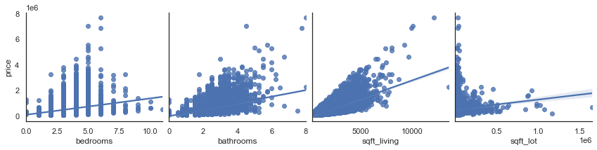

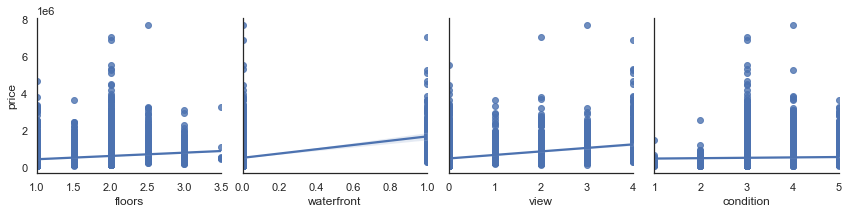

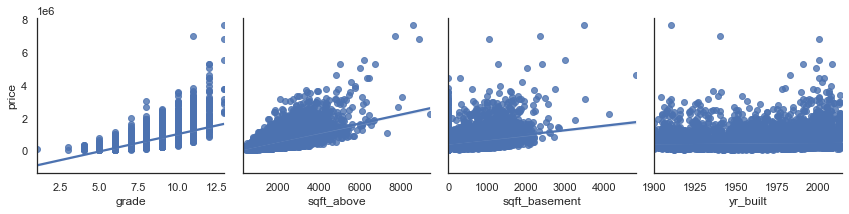

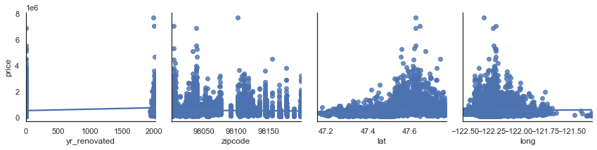

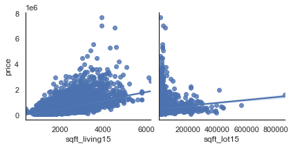

```python
#break the colums into groups to plot 4 on a row at a time
n = 4
row_groups= [features[i:i+n] for i in range(0, len(features), n) ]

for i in row_groups:
    pp = sns.pairplot(data=df, y_vars=['price'],x_vars=i, kind="reg", height=3, diag_kind=None)
```

## Variance Inflation Factor (VIF) redone

```python
# dropped 'sqft_above'
features_base=['bedrooms', 'bathrooms', 'sqft_living',  # excl id and bedrooms and 'date',
       'sqft_lot', 'floors', 'waterfront', 'view', 'condition', 'grade',
       'sqft_basement', 'yr_built', 'yr_renovated', 'zipcode',
       'lat', 'long', 'sqft_living15', 'sqft_lot15', #'date_formatted',
       ]

df_features_base = df[features_base]
```

```python
vif = pd.DataFrame()
vif["VIF Factor"] = [variance_inflation_factor(df_features_base.values, i) for i in range(df_features_base.shape[1])]
vif["features"] = df_features_base.columns
vif.round(1)
```

|  | VIF Factor | features |
| --- | --- | --- |
| 0 | 24.7 | bedrooms |
| 1 | 28.5 | bathrooms |
| 2 | 37.4 | sqft_living |
| 3 | 2.3 | sqft_lot |
| 4 | 16.8 | floors |
| 5 | 1.2 | waterfront |
| 6 | 1.6 | view |
| 7 | 34.5 | condition |
| 8 | 148.2 | grade |
| 9 | 2.8 | sqft_basement |
| 10 | 9550.1 | yr_built |
| 11 | 1.2 | yr_renovated |
| 12 | 1614133.2 | zipcode |
| 13 | 138947.9 | lat |
| 14 | 1345609.6 | long |
| 15 | 27.2 | sqft_living15 |
| 16 | 2.5 | sqft_lot15 |

## Step 2: Exploratory Data Analysis

To see if there are any extreme values and create data visualizations.

```python
sns.set_style('darkgrid')
sns.set_context('talk')
```

## Review waterfront properties

```python
waterfront = df[df['waterfront'] == 1]['price']
no_waterfront = df[df['waterfront'] == 0]['price']
```

```python
import scipy.stats as scs
t, p = scs.ttest_ind(waterfront, no_waterfront)
p_value = p
p_value
```

```
2.465038317654299e-299
```

H0: mu_waterfront = mu_no_waterfront H1: mu_waterfront != mu_no_waterfront Because p-value is less than 𝛼 = 0.05, reject H0.

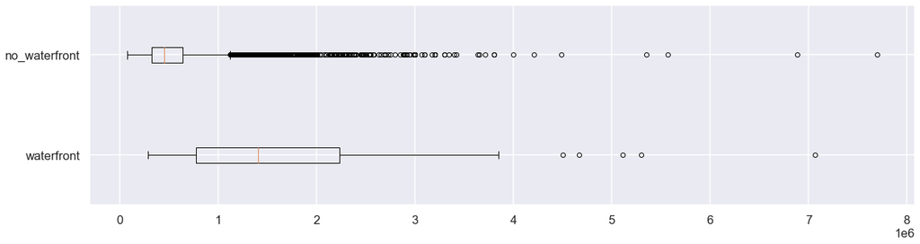

```python
fig, ax = plt.subplots(figsize = (20, 5))
ax.boxplot([waterfront, no_waterfront], vert = False, labels=['waterfront', 'no_waterfront']);
```

## Review price by sq ft living space

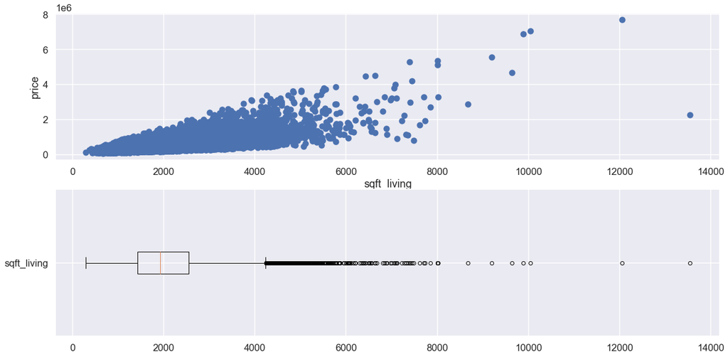

```python
fig, ax = plt.subplots(2, 1, figsize = (20, 10))
ax[0].scatter(df['sqft_living'], df['price'])
ax[0].set_xlabel('sqft_living')
ax[0].set_ylabel('price')
ax[1].boxplot(df['sqft_living'], vert = False, labels=['sqft_living']);
```

## Review price by sq ft lot space

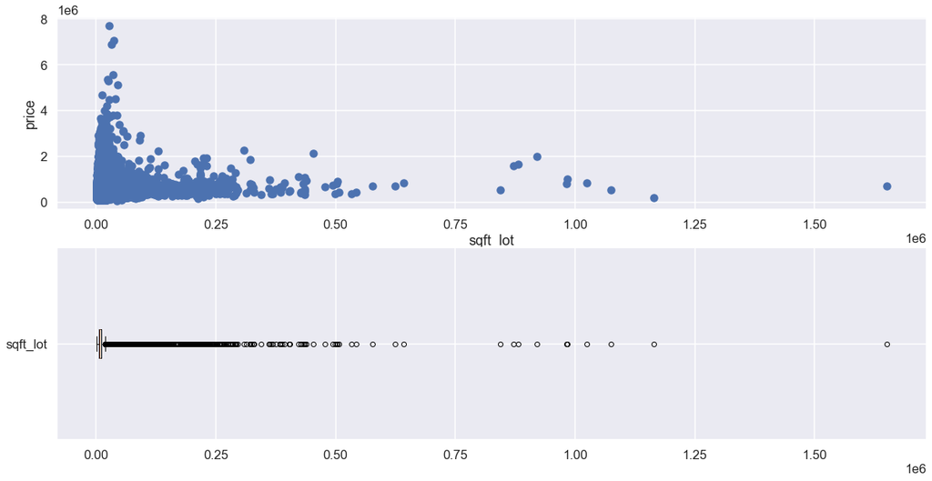

```python
fig, ax = plt.subplots(2, 1, figsize = (20, 10))
ax[0].scatter(df['sqft_lot'], df['price'])
ax[0].set_xlabel('sqft_lot')
ax[0].set_ylabel('price')
ax[1].boxplot(df['sqft_lot'], vert = False, labels=['sqft_lot']);
```

## Review price by year built

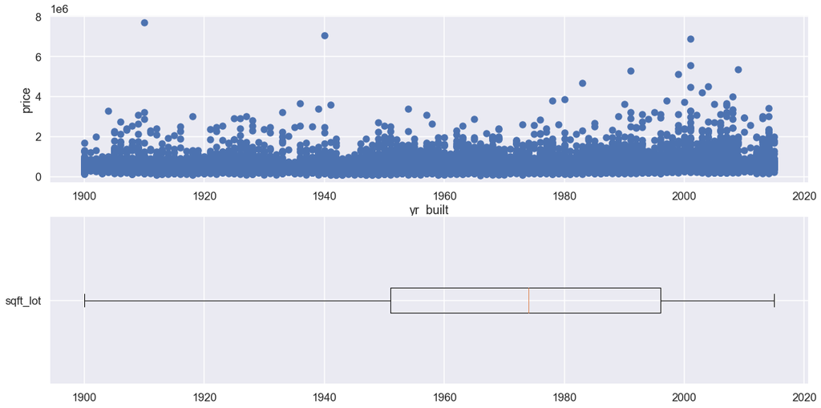

```python
fig, ax = plt.subplots(2, 1, figsize = (20, 10))
ax[0].scatter((df['yr_built']), df['price'])
ax[0].set_xlabel('yr_built')
ax[0].set_ylabel('price')
ax[1].boxplot(df['yr_built'], vert = False, labels=['sqft_lot']);
```

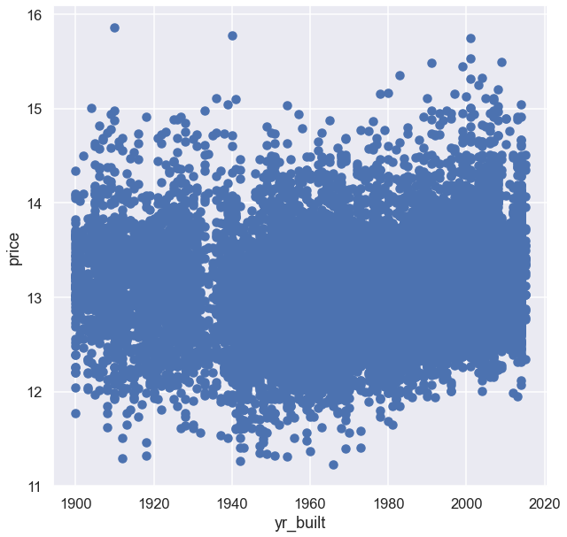

```python
fig, ax = plt.subplots(figsize = (10, 10))
ax.scatter((df['yr_built']), np.log(df['price']))
ax.set_xlabel('yr_built')
ax.set_ylabel('price');
```

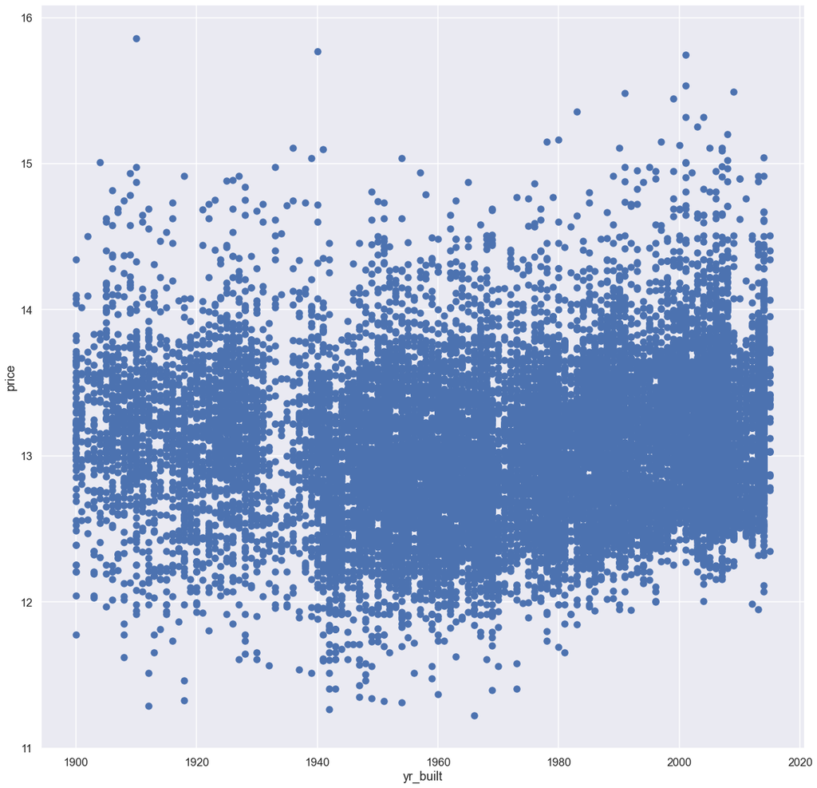

```python
fig, ax = plt.subplots(figsize = (20, 20))
ax.scatter(df['yr_built'], np.log(df['price']))
ax.set_xlabel('yr_built')
ax.set_ylabel('price');
```

```python
print(df['yr_built'].max())
print(df['yr_built'].min())
```

```
2015
1900
```

## Step 3: Capping and transformation

```python
# Cap sqft_living at 8,000 and sqft_lot at 800,000
df['sqft_living']= np.where(df['sqft_living'] >8000, 8000, df['sqft_living'])
df['sqft_lot']= np.where(df['sqft_lot'] >800000, 800000, df['sqft_lot'])
```

```python
# Some properties have 0 bedrooms but it's clearly an error. To account for that, set
# bedrooms=# of floors-1 if bedrooms=0
df['bedrooms']= np.where(df['bedrooms'] <1 , df['floors']-1, df['bedrooms'])
```

```python
# Some properties have 0 bathrooms but it's clearly an error. To account for that, set
# bathrooms=# of floors if bathrooms=0
df['bathrooms']= np.where(df['bathrooms'] <1, df['floors'], df['bathrooms'])
```

## Step 4: Generate new features.

### Identify a categorical variable in the data set and create dummy columns.

# Generate new feature "condition_text"

```python
df['condition_text']=df['condition']
df['condition_text']=np.where(df['condition']<3, 'low', df['condition_text'])
df['condition_text']=np.where(df['condition']==3, 'mid', df['condition_text'])
df['condition_text']=np.where(df['condition']>3, 'high', df['condition_text'])
```

```python
df['condition_text'].value_counts()
```

```
mid     11244
high     5883
low       163
Name: condition_text, dtype: int64
```

H0: mu_condition_low = mu_condition_mid = mu_condition_lhigh H1: H0 is not true ANOVA-test

```python
from statsmodels.formula.api import ols
import statsmodels.api as sm
# why can we use ols in this case?
anova_state = ols('price~condition_text', data = df).fit()
# anova_state.summary()

# examine the anova table
anova_table = sm.stats.anova_lm(anova_state, type=2)
print(anova_table)
```

```
                     df        sum_sq       mean_sq          F        PR(>F)
condition_text      2.0  6.593473e+12  3.296736e+12  23.717226  5.174224e-11
Residual        17287.0  2.402924e+15  1.390018e+11        NaN           NaN
```

```python
print('P-value of 5.174224e-11, thus reject the null hypothesis. Condition_text is statistically significant.')
```

```
P-value of 5.174224e-11, thus reject the null hypothesis. Condition_text is statistically significant.
```

# Generate new feature "grade_text"

```python
df['grade_text']=df['grade']
df['grade_text']=np.where(df['grade']<6, 'low', df['grade_text'])
df['grade_text']=np.where((df['grade']<8)&(df['grade']>5), 'mid_1', df['grade_text'])
df['grade_text']=np.where((df['grade']<10)&(df['grade']>7), 'mid_2', df['grade_text'])
df['grade_text']=np.where(df['grade']>9, 'high', df['grade_text'])
```

```python
df['grade_text'].value_counts()
```

```
mid_1    8831
mid_2    6947
high     1295
low       217
Name: grade_text, dtype: int64
```

H0: mu_grade_low = mu_grade_mid_1 = mu_grade_mid_2 = mu_grade_lhigh H1: H0 is not true ANOVA-test

```python
from statsmodels.formula.api import ols
import statsmodels.api as sm
# why can we use ols in this case?
anova_state = ols('price~grade_text', data = df).fit()
# anova_state.summary()

# examine the anova table
anova_table = sm.stats.anova_lm(anova_state, type=2)
print(anova_table)
```

```
                 df        sum_sq       mean_sq            F  PR(>F)
grade_text      3.0  9.693393e+14  3.231131e+14  3878.224768     0.0
Residual    17286.0  1.440178e+15  8.331469e+10          NaN     NaN
```

```python
print('P-value of 0.0, thus reject the null hypothesis. grade_text is statistically significant.')
```

```
P-value of 0.0, thus reject the null hypothesis. grade_text is statistically significant.
```

```python
# create dummy columns for condition_text' and 'grade_text'
df = pd.get_dummies(df, columns=['condition_text', 'grade_text'], drop_first=True)
```

# Generate new feature "zipcode_text"

```python
df.groupby('zipcode')['price'].aggregate(['mean', 'std', 'count']).sort_values(by='mean')
```

| zipcode | mean | std | count |
| --- | --- | --- | --- |
| 98002 | 2.322865e+05 | 5.332875e+04 | 157 |
| 98168 | 2.410415e+05 | 7.175406e+04 | 215 |
| 98032 | 2.516022e+05 | 6.470881e+04 | 103 |
| 98148 | 2.720823e+05 | 6.495523e+04 | 43 |
| 98001 | 2.819988e+05 | 9.940111e+04 | 284 |
| 98188 | 2.890318e+05 | 1.044765e+05 | 109 |
| 98023 | 2.895726e+05 | 1.136739e+05 | 410 |
| 98003 | 2.907627e+05 | 1.072202e+05 | 224 |
| 98030 | 2.964029e+05 | 7.370928e+04 | 201 |
| 98031 | 3.005987e+05 | 7.392874e+04 | 215 |
| 98198 | 3.051785e+05 | 1.596624e+05 | 220 |
| 98055 | 3.068521e+05 | 9.159672e+04 | 210 |
| 98022 | 3.087681e+05 | 1.129660e+05 | 189 |
| 98042 | 3.091687e+05 | 1.025196e+05 | 423 |
| 98178 | 3.126811e+05 | 1.653598e+05 | 215 |
| 98106 | 3.183727e+05 | 9.949839e+04 | 266 |
| 98092 | 3.397201e+05 | 1.266444e+05 | 286 |
| 98058 | 3.543642e+05 | 1.328835e+05 | 385 |
| 98108 | 3.560812e+05 | 1.045198e+05 | 151 |
| 98146 | 3.637469e+05 | 2.139704e+05 | 246 |
| 98038 | 3.684230e+05 | 1.389843e+05 | 455 |
| 98133 | 3.863916e+05 | 9.839990e+04 | 400 |
| 98118 | 4.117730e+05 | 2.265453e+05 | 410 |
| 98155 | 4.229997e+05 | 2.851065e+05 | 350 |
| 98056 | 4.234974e+05 | 2.392405e+05 | 336 |
| 98010 | 4.248736e+05 | 2.040606e+05 | 74 |
| 98126 | 4.250761e+05 | 1.552231e+05 | 278 |
| 98019 | 4.284222e+05 | 1.259290e+05 | 145 |
| 98045 | 4.313185e+05 | 1.910496e+05 | 176 |
| 98014 | 4.562057e+05 | 2.723450e+05 | 101 |
| 98028 | 4.684170e+05 | 1.598076e+05 | 219 |
| 98125 | 4.752226e+05 | 2.126291e+05 | 321 |
| 98166 | 4.793758e+05 | 3.163716e+05 | 209 |
| 98011 | 4.906393e+05 | 1.280995e+05 | 163 |
| 98059 | 4.943730e+05 | 2.352255e+05 | 373 |
| 98070 | 4.956727e+05 | 1.988705e+05 | 99 |
| 98034 | 5.238643e+05 | 3.279277e+05 | 435 |
| 98065 | 5.272174e+05 | 1.934769e+05 | 249 |
| 98136 | 5.659156e+05 | 2.632684e+05 | 214 |
| 98072 | 5.667307e+05 | 2.145114e+05 | 215 |
| 98117 | 5.701880e+05 | 1.885337e+05 | 437 |
| 98107 | 5.834824e+05 | 2.498425e+05 | 212 |
| 98103 | 5.897893e+05 | 2.037417e+05 | 461 |
| 98024 | 5.909915e+05 | 3.680076e+05 | 65 |
| 98007 | 5.975536e+05 | 1.862670e+05 | 122 |
| 98027 | 6.072946e+05 | 2.848574e+05 | 332 |
| 98115 | 6.137439e+05 | 2.330497e+05 | 465 |
| 98116 | 6.150221e+05 | 2.380988e+05 | 266 |
| 98029 | 6.156723e+05 | 1.932705e+05 | 250 |
| 98122 | 6.192377e+05 | 2.497202e+05 | 235 |
| 98144 | 6.213533e+05 | 4.332263e+05 | 269 |
| 98008 | 6.407492e+05 | 3.832813e+05 | 226 |
| 98052 | 6.460591e+05 | 1.910254e+05 | 474 |
| 98177 | 6.552490e+05 | 4.262835e+05 | 218 |
| 98077 | 6.768898e+05 | 2.663579e+05 | 162 |
| 98053 | 6.773342e+05 | 2.682728e+05 | 324 |
| 98074 | 6.912549e+05 | 2.784124e+05 | 358 |
| 98199 | 7.871469e+05 | 3.946048e+05 | 266 |
| 98075 | 7.939692e+05 | 2.999751e+05 | 286 |
| 98033 | 8.027175e+05 | 4.748570e+05 | 355 |
| 98005 | 8.088476e+05 | 2.727417e+05 | 140 |
| 98006 | 8.494588e+05 | 4.474201e+05 | 385 |
| 98105 | 8.687880e+05 | 4.823200e+05 | 170 |
| 98119 | 8.712724e+05 | 4.634903e+05 | 149 |
| 98109 | 8.759879e+05 | 4.905766e+05 | 85 |
| 98102 | 9.336715e+05 | 8.723511e+05 | 80 |
| 98112 | 1.119458e+06 | 6.234439e+05 | 216 |
| 98040 | 1.183018e+06 | 6.179093e+05 | 229 |
| 98004 | 1.396883e+06 | 7.980053e+05 | 237 |
| 98039 | 2.202790e+06 | 1.242894e+06 | 42 |

```python
zipcode_numbers = df.groupby('zipcode')['price'].aggregate(['mean', 'std']).sort_values(by='mean').index
```

```python
n = 10
zipcode_groups= [zipcode_numbers[i:i+n] for i in range(0, len(zipcode_numbers), n) ]
zipcode_groups
```

```
[Int64Index([98002, 98168, 98032, 98148, 98001, 98188, 98023, 98003, 98030,
             98031],
            dtype='int64', name='zipcode'),
 Int64Index([98198, 98055, 98022, 98042, 98178, 98106, 98092, 98058, 98108,
             98146],
            dtype='int64', name='zipcode'),
 Int64Index([98038, 98133, 98118, 98155, 98056, 98010, 98126, 98019, 98045,
             98014],
            dtype='int64', name='zipcode'),
 Int64Index([98028, 98125, 98166, 98011, 98059, 98070, 98034, 98065, 98136,
             98072],
            dtype='int64', name='zipcode'),
 Int64Index([98117, 98107, 98103, 98024, 98007, 98027, 98115, 98116, 98029,
             98122],
            dtype='int64', name='zipcode'),
 Int64Index([98144, 98008, 98052, 98177, 98077, 98053, 98074, 98199, 98075,
             98033],
            dtype='int64', name='zipcode'),
 Int64Index([98005, 98006, 98105, 98119, 98109, 98102, 98112, 98040, 98004,
             98039],
            dtype='int64', name='zipcode')]
```

[98002, 98168, 98032, 98148, 98001, 98188, 98023, 98003, 98030,98031], [98198, 98055, 98022, 98042, 98178, 98106, 98092, 98058, 98108,98146], [98038, 98133, 98118, 98155, 98056, 98010, 98126, 98019, 98045,98014], [98028, 98125, 98166, 98011, 98059, 98070, 98034, 98065, 98136,98072], [98117, 98107, 98103, 98024, 98007, 98027, 98115, 98116, 98029,98122], [98144, 98008, 98052, 98177, 98077, 98053, 98074, 98199, 98075,98033], [98005, 98006, 98105, 98119, 98109, 98102, 98112, 98040, 98004,98039]

```python
df['zipcode_text']=df['zipcode']
for zipcode in [98002, 98168, 98032, 98148, 98001, 98188, 98023, 98003, 98030,98031]:
    df['zipcode_text']=np.where(df['zipcode']==zipcode , 'n_1', df['zipcode_text'])
for zipcode in [98198, 98055, 98022, 98042, 98178, 98106, 98092, 98058, 98108,98146]:
    df['zipcode_text']=np.where(df['zipcode']==zipcode , 'n_2', df['zipcode_text'])
for zipcode in [98038, 98133, 98118, 98155, 98056, 98010, 98126, 98019, 98045,98014]:
    df['zipcode_text']=np.where(df['zipcode']==zipcode , 'n_3', df['zipcode_text'])
for zipcode in [98028, 98125, 98166, 98011, 98059, 98070, 98034, 98065, 98136,98072]:
    df['zipcode_text']=np.where(df['zipcode']==zipcode , 'n_4', df['zipcode_text'])
for zipcode in [98117, 98107, 98103, 98024, 98007, 98027, 98115, 98116, 98029,98122]:
    df['zipcode_text']=np.where(df['zipcode']==zipcode , 'n_5', df['zipcode_text'])
for zipcode in [98144, 98008, 98052, 98177, 98077, 98053, 98074, 98199, 98075,98033]:
    df['zipcode_text']=np.where(df['zipcode']==zipcode , 'n_6', df['zipcode_text'])
for zipcode in [98005, 98006, 98105, 98119, 98109, 98102, 98112, 98040, 98004,98039]:
    df['zipcode_text']=np.where(df['zipcode']==zipcode , 'n_7', df['zipcode_text'])
```

```python
# create dummy columns for zipcode_text'
df = pd.get_dummies(df, columns=['zipcode_text'], drop_first=True)
```

# Generate new feature "has_basement"

```python
basement = df[df['sqft_basement'] != 0]['price']
no_basement = df[df['sqft_basement'] == 0]['price']
```

H0: mu_basement = mu_no_basement H1: mu_basement != mu_no_basement Because p-value is less than 𝛼 = 0.05, reject H0.

```python
import scipy.stats as scs
t, p = scs.ttest_ind(basement, no_basement)
p_value = p
p_value
```

```
1.2107663322174255e-121
```

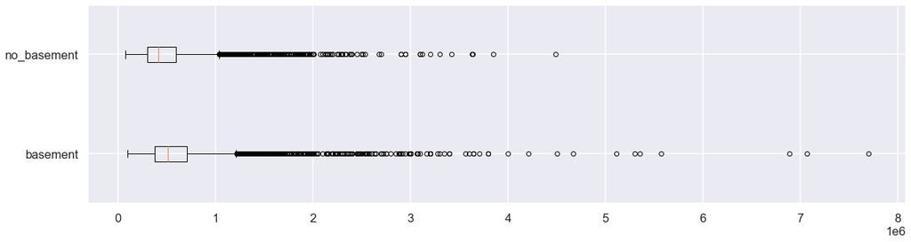

```python
fig, ax = plt.subplots(figsize = (20, 5))
ax.boxplot([basement, no_basement], vert = False, labels=['basement', 'no_basement']);
```

```python
# cap sqft_basement at 2,000
df['sqft_basement']= np.where(df['sqft_basement'] >2000, 2000, df['sqft_basement'])
```

```python
df['has_basement']= np.where(df['sqft_basement'] >0, 1, 0)
```

## Generate new features "bedrooms_5plus", "bedrooms_2.5minus" and "bathrooms_2.75plus"

```python
df['bedrooms_5plus']= np.where(df['bedrooms'] >4, 1, 0)
```

```python
df['bedrooms_2.5minus']= np.where(df['bedrooms'] <3, 1, 0)
```

```python
df['bathrooms_2.75plus']= np.where(df['bathrooms'] >2.5, 1, 0)
```

## Generate new feature "comp"

```python
by_zipcode = df.groupby(['zipcode','bedrooms_5plus','bedrooms_2.5minus', 'bathrooms_2.75plus'])['price'].mean()
by_zipcode
```

```
zipcode  bedrooms_5plus  bedrooms_2.5minus  bathrooms_2.75plus
98001    0               0                  0                     2.756042e+05
                                            1                     4.003529e+05
                         1                  0                     2.266342e+05
                                            1                     2.394750e+05
         1               0                  0                     2.922833e+05
                                                                      ...
98199    0               0                  0                     7.350559e+05
                                            1                     1.057727e+06
                         1                  0                     5.500873e+05
         1               0                  0                     8.711000e+05
                                            1                     1.445398e+06
Name: price, Length: 368, dtype: float64
```

```python
by_zipcode_dict = by_zipcode.to_dict()
```

```python
by_zipcode_dict
```

```
{(98001, 0, 0, 0): 275604.17467248905,
 (98001, 0, 0, 1): 400352.9411764706,
 (98001, 0, 1, 0): 226634.2105263158,
 (98001, 0, 1, 1): 239475.0,
 (98001, 1, 0, 0): 292283.3333333333,
 (98001, 1, 0, 1): 375178.2,
 (98002, 0, 0, 0): 229685.77586206896,
 (98002, 0, 0, 1): 286865.0,
 (98002, 0, 1, 0): 173978.15789473685,
 (98002, 1, 0, 0): 272066.6666666667,
 (98002, 1, 0, 1): 315000.0,
 (98003, 0, 0, 0): 275529.76136363635,
 (98003, 0, 0, 1): 381109.3125,
 (98003, 0, 1, 0): 224528.7857142857,
 (98003, 1, 0, 0): 362090.9090909091,
 (98003, 1, 0, 1): 487635.71428571426,
 (98004, 0, 0, 0): 1044594.0085470085,
 (98004, 0, 0, 1): 1725895.6949152541,
 (98004, 0, 1, 0): 867600.0,
 (98004, 1, 0, 0): 1221968.4210526317,
 (98004, 1, 0, 1): 2347578.125,
 (98005, 0, 0, 0): 727280.797752809,
 (98005, 0, 0, 1): 1020018.75,
 (98005, 0, 1, 1): 780000.0,
 (98005, 1, 0, 0): 733248.3076923077,
 (98005, 1, 0, 1): 1055230.7692307692,
 (98006, 0, 0, 0): 702494.9163179917,
 (98006, 0, 0, 1): 1124323.3333333333,
 (98006, 0, 1, 0): 879304.2857142857,
 (98006, 1, 0, 0): 763181.8,
 (98006, 1, 0, 1): 1207984.9361702127,
 (98007, 0, 0, 0): 580002.1627906977,
 (98007, 0, 0, 1): 769085.7142857143,
 (98007, 0, 1, 0): 454820.2,
 (98007, 1, 0, 0): 588603.125,
 (98007, 1, 0, 1): 743250.0,
 (98008, 0, 0, 0): 551798.1829268293,
 (98008, 0, 0, 1): 1007727.5,
 (98008, 0, 1, 0): 1208000.0,
 (98008, 1, 0, 0): 668602.7142857143,
```

[output cut: 313 more lines]

```
 (98188, 0, 0, 0): 277779.3108108108,
 (98188, 0, 0, 1): 407720.0,
 (98188, 0, 1, 0): 219296.42857142858,
 (98188, 1, 0, 0): 278000.0,
 (98188, 1, 0, 1): 384207.14285714284,
 (98198, 0, 0, 0): 294023.8275862069,
 (98198, 0, 0, 1): 508007.5,
 (98198, 0, 1, 0): 233379.375,
 (98198, 1, 0, 0): 299806.3076923077,
 (98198, 1, 0, 1): 556500.0,
 (98199, 0, 0, 0): 735055.9466666667,
 (98199, 0, 0, 1): 1057727.0212765958,
 (98199, 0, 1, 0): 550087.283018868,
 (98199, 1, 0, 0): 871100.0,
 (98199, 1, 0, 1): 1445398.1818181819}
```

```python
df['for_zipcode'] = [tuple(x) for x in df[['zipcode','bedrooms_5plus','bedrooms_2.5minus','bathrooms_2.75plus']].to_numpy()]
df['for_zipcode'][:10]
```

```
0    (98058, 0, 0, 0)
1    (98115, 1, 0, 1)
2    (98006, 0, 0, 0)
3    (98034, 0, 0, 1)
4    (98052, 0, 0, 0)
5    (98031, 0, 0, 0)
6    (98007, 0, 0, 0)
7    (98199, 0, 0, 0)
8    (98027, 0, 0, 0)
9    (98119, 0, 1, 0)
Name: for_zipcode, dtype: object
```

```python
df['comp'] = np.nan
df['comp'].fillna(df['for_zipcode'].map(by_zipcode_dict), inplace=True)
```

```python
df['comp']
```

```
0        336092.091228
1        921388.421053
2        702494.916318
3        881200.925926
4        615286.640118
             ...
17285    668602.714286
17286    543709.133333
17287    460955.575949
17288    352465.689560
17289    406595.570833
Name: comp, Length: 17290, dtype: float64
```

## Generate new feature "yr_sold"

```python
df['yr_sold']= df['date_formatted'].dt.year
```

## Generate new features "yr_since_update" and "yr_built_abs"

```python
df['yr_since_update']= np.where(df['yr_renovated'] ==0, df['yr_sold']-df['yr_built'], df['yr_sold']-df['yr_renovated'])
```

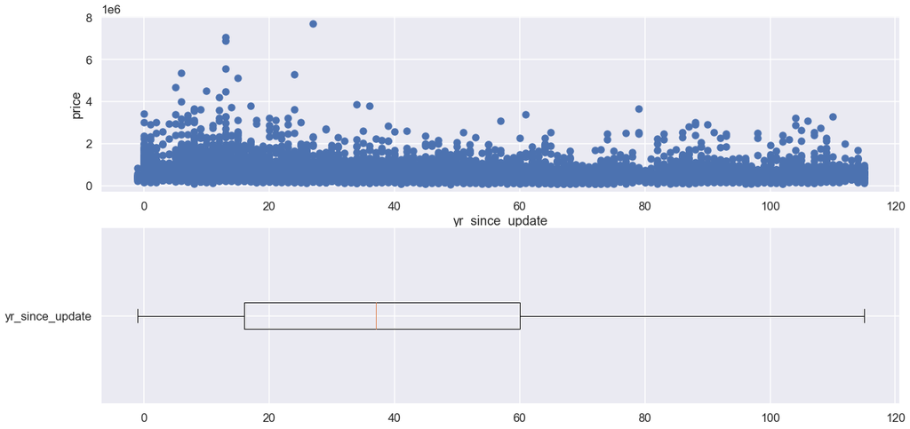

```python
fig, ax = plt.subplots(2, 1, figsize = (20, 10))
ax[0].scatter((df['yr_since_update']), df['price'])
ax[0].set_xlabel('yr_since_update')
ax[0].set_ylabel('price')
ax[1].boxplot(df['yr_since_update'], vert = False, labels=['yr_since_update']);
```

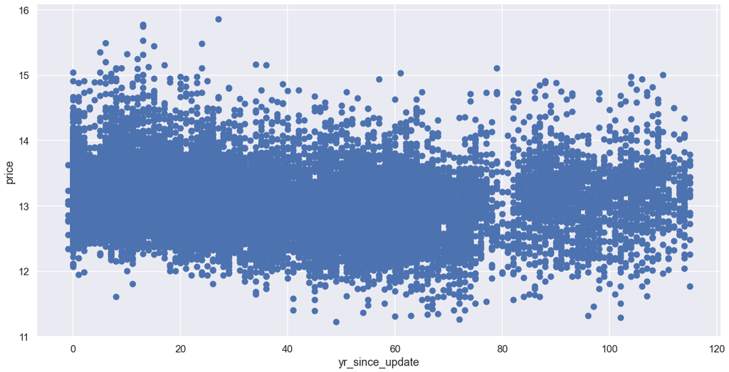

```python
fig, ax = plt.subplots(figsize = (20, 10))
ax.scatter((df['yr_since_update']), np.log(df['price']))
ax.set_xlabel('yr_since_update')
ax.set_ylabel('price');
```

```python
print(df['yr_built'].max())
print(df['yr_built'].min())
yr_built_avg = (df['yr_built'].max()+df['yr_built'].min())/2
print(yr_built_avg)
```

```
2015
1900
1957.5
```

```python
df['yr_built_abs'] = abs(1958-df['yr_built'])
```

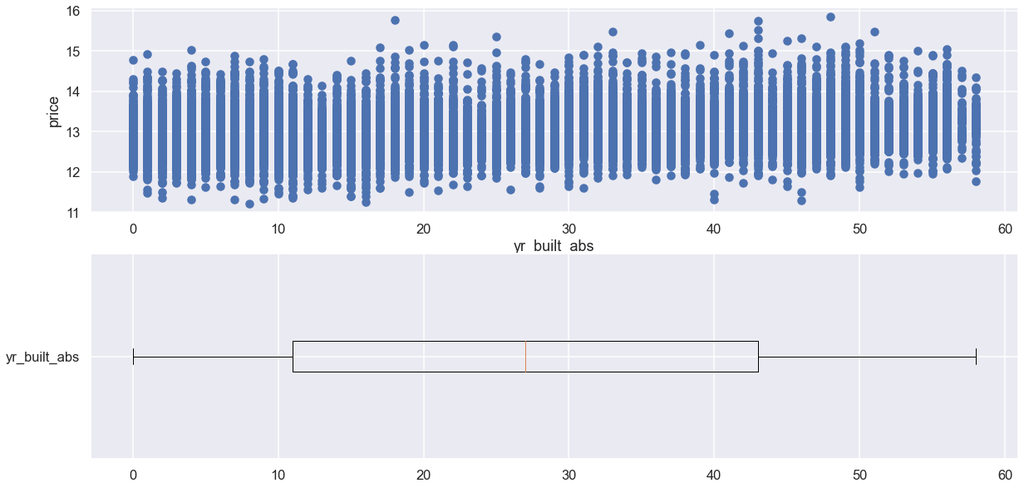

```python
fig, ax = plt.subplots(2, 1, figsize = (20, 10))
ax[0].scatter((df['yr_built_abs']), np.log(df['price']))
ax[0].set_xlabel('yr_built_abs')
ax[0].set_ylabel('price')
ax[1].boxplot(df['yr_built_abs'], vert = False, labels=['yr_built_abs']);
```

## Step 5: 2nd degree polynomial with no categorical interactions

```python
# excl id and 'date', #'grade',  'condition', # 'zipcode',#'date_formatted', 'long',
# 'for_zipcode', 'yr_sold',
features_3=['bedrooms', 'bathrooms', 'sqft_living',
       'sqft_lot', 'floors', 'waterfront', 'view',
       'sqft_basement', 'yr_built', 'yr_renovated',
       'lat', 'sqft_living15', 'sqft_lot15',
       'condition_text_low', 'condition_text_mid', 'grade_text_low',
       'grade_text_mid_1', 'grade_text_mid_2', 'has_basement',
       'zipcode_text_n_2', 'zipcode_text_n_3', 'zipcode_text_n_4',
       'zipcode_text_n_5', 'zipcode_text_n_6', 'zipcode_text_n_7',
       'bedrooms_5plus', 'bathrooms_2.75plus', 'comp', 'bedrooms_2.5minus',
       'yr_since_update', 'yr_built_abs']

df_features_3 = df[features_3]
```

```python
contin_vars = ['bedrooms', 'bathrooms', 'sqft_living', 'sqft_lot', 'floors',
       'waterfront', 'view', 'sqft_basement', 'yr_built',
       'yr_renovated', 'lat', 'sqft_living15', 'sqft_lot15',
       'comp', 'yr_since_update', 'yr_built_abs']
```

```python
poly_2 = PolynomialFeatures(degree=2, include_bias=False)
poly2_data = poly_2.fit_transform(df_features_3[contin_vars])
poly2_columns = poly_2.get_feature_names(df_features_3.columns)
df_poly2 = pd.DataFrame(poly2_data, columns=poly2_columns)
df_poly2.head()
```

|  | bedrooms | bathrooms | sqft_living | sqft_lot | floors | waterfront | view | sqft_basement | yr_built | yr_renovated | lat | sqft_living15 | sqft_lot15 | condition_text_low | condition_text_mid | grade_text_low | bedrooms^2 | bedrooms bathrooms | bedrooms sqft_living | bedrooms sqft_lot | bedrooms floors | bedrooms waterfront | bedrooms view | bedrooms sqft_basement | bedrooms yr_built | bedrooms yr_renovated | bedrooms lat | bedrooms sqft_living15 | bedrooms sqft_lot15 | … |
| --- | --- | --- | --- | --- | --- | --- | --- | --- | --- | --- | --- | --- | --- | --- | --- | --- | --- | --- | --- | --- | --- | --- | --- | --- | --- | --- | --- | --- | --- | --- |
| 0 | 4.0 | 2.25 | 2070.0 | 8893.0 | 2.0 | 0.0 | 0.0 | 0.0 | 1986.0 | 0.0 | 47.4388 | 2390.0 | 7700.0 | 336092.091228 | 28.0 | 28.0 | 16.0 | 9.0 | 8280.0 | 35572.0 | 8.0 | 0.0 | 0.0 | 0.0 | 7944.0 | 0.0 | 189.7552 | 9560.0 | 30800.0 | … |
| 1 | 5.0 | 3.00 | 2900.0 | 6730.0 | 1.0 | 0.0 | 0.0 | 1070.0 | 1977.0 | 0.0 | 47.6784 | 2370.0 | 6283.0 | 921388.421053 | 37.0 | 19.0 | 25.0 | 15.0 | 14500.0 | 33650.0 | 5.0 | 0.0 | 0.0 | 5350.0 | 9885.0 | 0.0 | 238.3920 | 11850.0 | 31415.0 | … |
| 2 | 4.0 | 2.50 | 3770.0 | 10893.0 | 2.0 | 0.0 | 2.0 | 0.0 | 1997.0 | 0.0 | 47.5646 | 3710.0 | 9685.0 | 702494.916318 | 17.0 | 39.0 | 16.0 | 10.0 | 15080.0 | 43572.0 | 8.0 | 0.0 | 8.0 | 0.0 | 7988.0 | 0.0 | 190.2584 | 14840.0 | 38740.0 | … |
| 3 | 3.0 | 3.50 | 4560.0 | 14608.0 | 2.0 | 0.0 | 2.0 | 0.0 | 1990.0 | 0.0 | 47.6995 | 4050.0 | 14226.0 | 881200.925926 | 25.0 | 32.0 | 9.0 | 10.5 | 13680.0 | 43824.0 | 6.0 | 0.0 | 6.0 | 0.0 | 5970.0 | 0.0 | 143.0985 | 12150.0 | 42678.0 | … |
| 4 | 3.0 | 2.50 | 2550.0 | 5376.0 | 2.0 | 0.0 | 0.0 | 0.0 | 2004.0 | 0.0 | 47.6647 | 2250.0 | 4050.0 | 615286.640118 | 10.0 | 46.0 | 9.0 | 7.5 | 7650.0 | 16128.0 | 6.0 | 0.0 | 0.0 | 0.0 | 6012.0 | 0.0 | 142.9941 | 6750.0 | 12150.0 | … |

```python
cat_vars = [x for x in df_features_3.columns if x not in contin_vars]
df_poly_cat = pd.concat([df_poly2, df_features_3[cat_vars]], axis=1)
```

```python
df_poly_cat.shape
```

```
(17290, 167)
```

```python
X_train, X_test, y_train, y_test = train_test_split(df_poly_cat, target, random_state=9, test_size=0.2)
```

```python
# instantiate a linear regression object
lm_2 = LinearRegression()

#fit the linear regression to the data
lm_2 = lm_2.fit(X_train, y_train)

y_train_pred = lm_2.predict(X_train)

train_rmse = np.sqrt(metrics.mean_squared_error(y_train, y_train_pred))
print('Training Root Mean Squared Error:' , train_rmse)
```

```
Training Root Mean Squared Error: 130506.66472075226
```

```python
# use fitted model to predict on test data
y_pred = lm_2.predict(X_test)

test_rmse = np.sqrt(metrics.mean_squared_error(y_test, y_pred))

print('Testing Root Mean Squared Error:' , test_rmse)
print('Training: ', int(train_rmse), "vs. Testing: ", int(test_rmse))
```

```
Testing Root Mean Squared Error: 125236.55281012342
Training:  130506 vs. Testing:  125236
```

## RFE

```python
ols = linear_model.LinearRegression()

# Create recursive feature eliminator that scores features by mean squared errors
selector = RFECV(estimator=ols, step=1, cv=5, scoring='neg_mean_squared_error', n_jobs=-1, verbose=1)

# Fit recursive feature eliminator
selector.fit(X_train, y_train)
```

```
Fitting estimator with 167 features.
Fitting estimator with 166 features.
Fitting estimator with 165 features.
Fitting estimator with 164 features.
Fitting estimator with 163 features.
```

```
RFECV(cv=5, estimator=LinearRegression(), n_jobs=-1,
      scoring='neg_mean_squared_error', verbose=1)
```

```python
selected_rfe = X_train.columns[selector.support_]
removed_rfe = X_train.columns[~selector.support_]
list(removed_rfe)
```

```
['sqft_lot^2',
 'sqft_lot sqft_lot15',
 'sqft_lot condition_text_low',
 'sqft_lot15^2',
 'condition_text_low^2']
```

```python
len(list(selected_rfe))
```

```
162
```

```python
selected_rfe
```

```
Index(['bedrooms', 'bathrooms', 'sqft_living', 'sqft_lot', 'floors',
       'waterfront', 'view', 'sqft_basement', 'yr_built', 'yr_renovated',
       ...
       'has_basement', 'zipcode_text_n_2', 'zipcode_text_n_3',
       'zipcode_text_n_4', 'zipcode_text_n_5', 'zipcode_text_n_6',
       'zipcode_text_n_7', 'bedrooms_5plus', 'bathrooms_2.75plus',
       'bedrooms_2.5minus'],
      dtype='object', length=162)
```

```python
#instantiate a linear regression object
lm_rfe = LinearRegression()

#fit the linear regression to the data
lm_rfe = lm_rfe.fit(X_train[selected_rfe], y_train)

y_rfe = lm_rfe.predict(X_train[selected_rfe])


trainRFE_rmse = np.sqrt(metrics.mean_squared_error(y_train, y_rfe))


print('Training Root Mean Squared Error:' , trainRFE_rmse)

y_pred_rfe = lm_rfe.predict(X_test[selected_rfe])

testRFE_rmse = np.sqrt(metrics.mean_squared_error(y_test, y_pred_rfe))

print('Testing Root Mean Squared Error:' , testRFE_rmse)
```

```
Training Root Mean Squared Error: 130843.25381942355
Testing Root Mean Squared Error: 126931.4726648362
```

## F-test

```python
X_train.shape
```

```
(13832, 167)
```

```python
selector = SelectKBest(f_regression, k=130) # is roughly equal to sqrt of 1720 observations

selector.fit(X_train, y_train)
selector.get_support()
selected_columns = X_train.columns[selector.get_support()]
removed_columns = X_train.columns[~selector.get_support()]
```

```python
list(removed_columns)
```

```
['sqft_lot',
 'yr_built',
 'yr_renovated',
 'sqft_lot15',
 'condition_text_mid',
 'bedrooms sqft_lot15',
 'bedrooms condition_text_mid',
 'sqft_lot^2',
 'sqft_lot yr_built',
 'sqft_lot yr_renovated',
 'sqft_lot lat',
 'sqft_lot sqft_lot15',
 'sqft_lot condition_text_mid',
 'floors sqft_lot15',
 'floors condition_text_mid',
 'yr_built^2',
 'yr_built yr_renovated',
 'yr_built lat',
 'yr_built sqft_lot15',
 'yr_built condition_text_mid',
 'yr_renovated^2',
 'yr_renovated lat',
 'yr_renovated sqft_lot15',
 'yr_renovated condition_text_mid',
 'yr_renovated grade_text_low',
 'lat sqft_lot15',
 'lat condition_text_mid',
 'sqft_lot15^2',
 'sqft_lot15 condition_text_mid',
 'sqft_lot15 grade_text_low',
 'condition_text_mid^2',
 'condition_text_mid grade_text_low',
 'condition_text_low',
 'condition_text_mid',
 'grade_text_low',
 'zipcode_text_n_4',
 'zipcode_text_n_5']
```

```python
list(selected_columns)
```

```
['bedrooms',
 'bathrooms',
 'sqft_living',
 'floors',
 'waterfront',
 'view',
 'sqft_basement',
 'lat',
 'sqft_living15',
 'condition_text_low',
 'grade_text_low',
 'bedrooms^2',
 'bedrooms bathrooms',
 'bedrooms sqft_living',
 'bedrooms sqft_lot',
 'bedrooms floors',
 'bedrooms waterfront',
 'bedrooms view',
 'bedrooms sqft_basement',
 'bedrooms yr_built',
 'bedrooms yr_renovated',
 'bedrooms lat',
 'bedrooms sqft_living15',
 'bedrooms condition_text_low',
 'bedrooms grade_text_low',
 'bathrooms^2',
 'bathrooms sqft_living',
 'bathrooms sqft_lot',
 'bathrooms floors',
 'bathrooms waterfront',
 'bathrooms view',
 'bathrooms sqft_basement',
 'bathrooms yr_built',
 'bathrooms yr_renovated',
 'bathrooms lat',
 'bathrooms sqft_living15',
 'bathrooms sqft_lot15',
 'bathrooms condition_text_low',
 'bathrooms condition_text_mid',
 'bathrooms grade_text_low',
```

[output cut: 75 more lines]

```
 'sqft_lot15 condition_text_low',
 'condition_text_low^2',
 'condition_text_low condition_text_mid',
 'condition_text_low grade_text_low',
 'grade_text_low^2',
 'grade_text_mid_1',
 'grade_text_mid_2',
 'has_basement',
 'zipcode_text_n_2',
 'zipcode_text_n_3',
 'zipcode_text_n_6',
 'zipcode_text_n_7',
 'bedrooms_5plus',
 'bathrooms_2.75plus',
 'bedrooms_2.5minus']
```

```python
len(list(selected_columns))
```

```
130
```

```python
#instantiate a linear regression object
lm_kbest = LinearRegression()

#fit the linear regression to the data
lm_kbest.fit(X_train[selected_columns], y_train)

y_train_kbest = lm_kbest.predict(X_train[selected_columns])


trainK_rmse = np.sqrt(metrics.mean_squared_error(y_train, y_train_kbest))


print('Training Root Mean Squared Error:' , trainK_rmse)

y_kbest = lm_kbest.predict(X_test[selected_columns])

testK_rmse = np.sqrt(metrics.mean_squared_error(y_test, y_kbest))

print('Testing Root Mean Squared Error:' , testK_rmse)
```

```
Training Root Mean Squared Error: 133869.7156933446
Testing Root Mean Squared Error: 127375.48349028321
```

```python
print('Original: ', test_rmse, '\n',
      "KBest:   ", testK_rmse,'\n',
      "RFE:     ", testRFE_rmse)
```

```
Original:  125236.55281012342
 KBest:    127375.48349028321
 RFE:      126931.4726648362
```

## Step 6: Refit the model to the entire dataset

```python
lm_final = LinearRegression()

#fit the linear regression to the data
lm_final = lm.fit(df_poly_cat[selected_columns], df['price'])
```

```python
df_poly_cat.shape
```

```
(17290, 167)
```

```python
df_poly_cat[selected_columns]
```

|  | bedrooms | bathrooms | sqft_living | floors | waterfront | view | sqft_basement | lat | sqft_living15 | condition_text_low | condition_text_low | grade_text_low | grade_text_low | bedrooms^2 | bedrooms bathrooms | bedrooms sqft_living | bedrooms sqft_lot | bedrooms floors | bedrooms waterfront | bedrooms view | bedrooms sqft_basement | bedrooms yr_built | bedrooms yr_renovated | bedrooms lat | bedrooms sqft_living15 | bedrooms condition_text_low | bedrooms grade_text_low | bathrooms^2 | bathrooms sqft_living | … |
| --- | --- | --- | --- | --- | --- | --- | --- | --- | --- | --- | --- | --- | --- | --- | --- | --- | --- | --- | --- | --- | --- | --- | --- | --- | --- | --- | --- | --- | --- | --- |
| 0 | 4.0 | 2.25 | 2070.0 | 2.0 | 0.0 | 0.0 | 0.0 | 47.4388 | 2390.0 | 336092.091228 | 0 | 28.0 | 0 | 16.0 | 9.0 | 8280.0 | 35572.0 | 8.0 | 0.0 | 0.0 | 0.0 | 7944.0 | 0.0 | 189.7552 | 9560.0 | 1.344368e+06 | 112.0 | 5.0625 | 4657.5 | … |
| 1 | 5.0 | 3.00 | 2900.0 | 1.0 | 0.0 | 0.0 | 1070.0 | 47.6784 | 2370.0 | 921388.421053 | 0 | 19.0 | 0 | 25.0 | 15.0 | 14500.0 | 33650.0 | 5.0 | 0.0 | 0.0 | 5350.0 | 9885.0 | 0.0 | 238.3920 | 11850.0 | 4.606942e+06 | 95.0 | 9.0000 | 8700.0 | … |
| 2 | 4.0 | 2.50 | 3770.0 | 2.0 | 0.0 | 2.0 | 0.0 | 47.5646 | 3710.0 | 702494.916318 | 0 | 39.0 | 0 | 16.0 | 10.0 | 15080.0 | 43572.0 | 8.0 | 0.0 | 8.0 | 0.0 | 7988.0 | 0.0 | 190.2584 | 14840.0 | 2.809980e+06 | 156.0 | 6.2500 | 9425.0 | … |
| 3 | 3.0 | 3.50 | 4560.0 | 2.0 | 0.0 | 2.0 | 0.0 | 47.6995 | 4050.0 | 881200.925926 | 0 | 32.0 | 0 | 9.0 | 10.5 | 13680.0 | 43824.0 | 6.0 | 0.0 | 6.0 | 0.0 | 5970.0 | 0.0 | 143.0985 | 12150.0 | 2.643603e+06 | 96.0 | 12.2500 | 15960.0 | … |
| 4 | 3.0 | 2.50 | 2550.0 | 2.0 | 0.0 | 0.0 | 0.0 | 47.6647 | 2250.0 | 615286.640118 | 0 | 46.0 | 0 | 9.0 | 7.5 | 7650.0 | 16128.0 | 6.0 | 0.0 | 0.0 | 0.0 | 6012.0 | 0.0 | 142.9941 | 6750.0 | 1.845860e+06 | 138.0 | 6.2500 | 6375.0 | … |
| ... | ... | ... | ... | ... | ... | ... | ... | ... | ... | ... | ... | ... | ... | ... | ... | ... | ... | ... | ... | ... | ... | ... | ... | ... | ... | ... | ... | ... | ... | … |
| 17285 | 5.0 | 2.50 | 3240.0 | 1.0 | 0.0 | 1.0 | 1220.0 | 47.5858 | 2730.0 | 668602.714286 | 0 | 0.0 | 0 | 25.0 | 12.5 | 16200.0 | 49800.0 | 5.0 | 0.0 | 5.0 | 6100.0 | 9790.0 | 0.0 | 237.9290 | 13650.0 | 3.343014e+06 | 0.0 | 6.2500 | 8100.0 | … |
| 17286 | 2.0 | 1.75 | 1300.0 | 2.0 | 0.0 | 0.0 | 0.0 | 47.6687 | 1350.0 | 543709.133333 | 0 | 10.0 | 0 | 4.0 | 3.5 | 2600.0 | 8000.0 | 4.0 | 0.0 | 0.0 | 0.0 | 3896.0 | 0.0 | 95.3374 | 2700.0 | 1.087418e+06 | 20.0 | 3.0625 | 2275.0 | … |
| 17287 | 3.0 | 1.00 | 1050.0 | 1.0 | 0.0 | 0.0 | 0.0 | 47.7635 | 1760.0 | 460955.575949 | 0 | 5.0 | 0 | 9.0 | 3.0 | 3150.0 | 29628.0 | 3.0 | 0.0 | 0.0 | 0.0 | 5859.0 | 0.0 | 143.2905 | 5280.0 | 1.382867e+06 | 15.0 | 1.0000 | 1050.0 | … |
| 17288 | 3.0 | 1.50 | 1900.0 | 1.5 | 0.0 | 0.0 | 600.0 | 47.4199 | 2080.0 | 352465.689560 | 0 | 13.0 | 0 | 9.0 | 4.5 | 5700.0 | 129558.0 | 4.5 | 0.0 | 0.0 | 1800.0 | 5913.0 | 0.0 | 142.2597 | 6240.0 | 1.057397e+06 | 39.0 | 2.2500 | 2850.0 | … |
| 17289 | 3.0 | 1.50 | 1330.0 | 1.0 | 0.0 | 0.0 | 0.0 | 47.7366 | 1320.0 | 406595.570833 | 0 | 6.0 | 0 | 9.0 | 4.5 | 3990.0 | 20304.0 | 3.0 | 0.0 | 0.0 | 0.0 | 5856.0 | 0.0 | 143.2098 | 3960.0 | 1.219787e+06 | 18.0 | 2.2500 | 1995.0 | … |

17290 rows × 132 columns

```python
lm.coef_
```

```
array([-1.08006250e+06, -8.28327567e+05,  5.89202706e+03, -1.86609923e+06,
       -3.29708632e+07, -1.30872012e+06, -3.19173420e+03,  5.72311675e+07,
        3.21291051e+03, -5.00980863e+01, -5.78881796e+04, -1.29174544e+05,
       -2.05058188e+05,  2.01586785e+03, -3.43099570e+03, -2.40289692e+01,
        6.91568291e-02,  2.21493051e+04,  6.48398392e+04, -8.79975823e+03,
        1.40392902e+01,  3.78006590e+02, -8.77870219e+00,  8.13329380e+03,
       -1.52296853e+00, -6.23800303e-02, -3.87602446e+02,  1.66282045e+04,
       -5.07883882e+00, -7.38227875e-02,  6.17347699e+03,  1.16210712e+05,
       -3.31125338e+03,  2.82137276e+01,  1.32714703e+03,  3.69024490e+01,
       -3.94700125e+04, -1.37835236e+01,  3.46189259e-01,  5.46353578e-03,
        1.64734326e+03,  1.36244839e+02,  3.86305153e-03,  3.52878124e-05,
       -2.47764509e+01,  1.23021627e+02,  1.43148108e+01, -1.91179382e-02,
       -3.18544086e+00, -3.66525219e-02,  1.13858345e+01,  8.13720608e-03,
       -1.92152336e-04,  2.36092135e-04, -2.84513955e+00,  2.31343912e+00,
        1.94165432e-01,  6.22946635e-01, -7.72352844e-02, -7.40401447e-07,
        9.72608104e-05, -9.79751348e-07,  6.85920659e-03,  2.58067163e+04,
       -2.16333301e+05,  3.10094463e+03,  9.63499765e+00, -6.74435520e+02,
       -1.81126230e+01,  6.47415140e+04,  2.81403064e+01, -1.10824890e-01,
       -5.69988762e+02, -5.34363151e+07, -3.67937517e+03, -3.66975744e+01,
       -1.81555245e+03, -1.76321163e+02,  1.89660112e+06,  5.51618774e+01,
        1.15463894e+00, -1.58034770e-01, -4.69645632e+03,  9.03114995e+02,
        1.12449484e+04, -4.92881933e+00, -3.39143020e+02, -5.74563438e+00,
        4.20815752e+04, -1.03989682e+01, -2.68355373e-02,  5.24337929e-02,
       -3.70322644e+02,  4.47306773e+00,  7.78551641e-03,  1.02693389e+00,
        7.70867764e-03,  2.33223125e+01,  8.30378674e-04, -4.84643970e-04,
       -1.34214759e-04,  7.21402517e-01, -9.46724636e-01, -6.33970881e-03,
        2.65277922e-05,  5.17698230e+01,  3.23176766e-02,  2.29924917e-05,
       -6.04033450e+05, -6.85271399e+01,  1.06331898e+00,  5.88099081e+02,
        2.24342337e-03,  1.74977817e-04,  8.78931023e-05,  1.26464475e+00,
       -1.56363246e+00, -1.55717134e-06, -2.14902684e-07,  2.87626870e-04,
        8.25606287e-04,  2.07835832e+01, -1.65803327e+05, -1.08400844e+05,
        1.54097342e+04, -1.11594696e+04, -6.04643452e+03, -4.91755569e+04,
        1.66492127e+04, -2.88429984e+04, -1.71109523e+05,  5.89319033e+04])
```

## Step 7: Save the final model using pickle.

```python
import pickle


pickle_out = open("pickle_files/model.pickle","wb")
pickle.dump(lm_final, pickle_out)
pickle_out.close()
```

```python
by_zipcode_dict
```

```
{(98001, 0, 0, 0): 275604.17467248905,
 (98001, 0, 0, 1): 400352.9411764706,
 (98001, 0, 1, 0): 226634.2105263158,
 (98001, 0, 1, 1): 239475.0,
 (98001, 1, 0, 0): 292283.3333333333,
 (98001, 1, 0, 1): 375178.2,
 (98002, 0, 0, 0): 229685.77586206896,
 (98002, 0, 0, 1): 286865.0,
 (98002, 0, 1, 0): 173978.15789473685,
 (98002, 1, 0, 0): 272066.6666666667,
 (98002, 1, 0, 1): 315000.0,
 (98003, 0, 0, 0): 275529.76136363635,
 (98003, 0, 0, 1): 381109.3125,
 (98003, 0, 1, 0): 224528.7857142857,
 (98003, 1, 0, 0): 362090.9090909091,
 (98003, 1, 0, 1): 487635.71428571426,
 (98004, 0, 0, 0): 1044594.0085470085,
 (98004, 0, 0, 1): 1725895.6949152541,
 (98004, 0, 1, 0): 867600.0,
 (98004, 1, 0, 0): 1221968.4210526317,
 (98004, 1, 0, 1): 2347578.125,
 (98005, 0, 0, 0): 727280.797752809,
 (98005, 0, 0, 1): 1020018.75,
 (98005, 0, 1, 1): 780000.0,
 (98005, 1, 0, 0): 733248.3076923077,
 (98005, 1, 0, 1): 1055230.7692307692,
 (98006, 0, 0, 0): 702494.9163179917,
 (98006, 0, 0, 1): 1124323.3333333333,
 (98006, 0, 1, 0): 879304.2857142857,
 (98006, 1, 0, 0): 763181.8,
 (98006, 1, 0, 1): 1207984.9361702127,
 (98007, 0, 0, 0): 580002.1627906977,
 (98007, 0, 0, 1): 769085.7142857143,
 (98007, 0, 1, 0): 454820.2,
 (98007, 1, 0, 0): 588603.125,
 (98007, 1, 0, 1): 743250.0,
 (98008, 0, 0, 0): 551798.1829268293,
 (98008, 0, 0, 1): 1007727.5,
 (98008, 0, 1, 0): 1208000.0,
 (98008, 1, 0, 0): 668602.7142857143,
```

[output cut: 313 more lines]

```
 (98188, 0, 0, 0): 277779.3108108108,
 (98188, 0, 0, 1): 407720.0,
 (98188, 0, 1, 0): 219296.42857142858,
 (98188, 1, 0, 0): 278000.0,
 (98188, 1, 0, 1): 384207.14285714284,
 (98198, 0, 0, 0): 294023.8275862069,
 (98198, 0, 0, 1): 508007.5,
 (98198, 0, 1, 0): 233379.375,
 (98198, 1, 0, 0): 299806.3076923077,
 (98198, 1, 0, 1): 556500.0,
 (98199, 0, 0, 0): 735055.9466666667,
 (98199, 0, 0, 1): 1057727.0212765958,
 (98199, 0, 1, 0): 550087.283018868,
 (98199, 1, 0, 0): 871100.0,
 (98199, 1, 0, 1): 1445398.1818181819}
```

```python
list(selected_columns)
```

```
['bedrooms',
 'bathrooms',
 'sqft_living',
 'floors',
 'waterfront',
 'view',
 'sqft_basement',
 'lat',
 'sqft_living15',
 'condition_text_low',
 'grade_text_low',
 'bedrooms^2',
 'bedrooms bathrooms',
 'bedrooms sqft_living',
 'bedrooms sqft_lot',
 'bedrooms floors',
 'bedrooms waterfront',
 'bedrooms view',
 'bedrooms sqft_basement',
 'bedrooms yr_built',
 'bedrooms yr_renovated',
 'bedrooms lat',
 'bedrooms sqft_living15',
 'bedrooms condition_text_low',
 'bedrooms grade_text_low',
 'bathrooms^2',
 'bathrooms sqft_living',
 'bathrooms sqft_lot',
 'bathrooms floors',
 'bathrooms waterfront',
 'bathrooms view',
 'bathrooms sqft_basement',
 'bathrooms yr_built',
 'bathrooms yr_renovated',
 'bathrooms lat',
 'bathrooms sqft_living15',
 'bathrooms sqft_lot15',
 'bathrooms condition_text_low',
 'bathrooms condition_text_mid',
 'bathrooms grade_text_low',
```

[output cut: 75 more lines]

```
 'sqft_lot15 condition_text_low',
 'condition_text_low^2',
 'condition_text_low condition_text_mid',
 'condition_text_low grade_text_low',
 'grade_text_low^2',
 'grade_text_mid_1',
 'grade_text_mid_2',
 'has_basement',
 'zipcode_text_n_2',
 'zipcode_text_n_3',
 'zipcode_text_n_6',
 'zipcode_text_n_7',
 'bedrooms_5plus',
 'bathrooms_2.75plus',
 'bedrooms_2.5minus']
```

```python
other_info = [by_zipcode_dict, list(selected_columns)]
```

```python
pickle_out = open('pickle_files/other_info.pickle', "wb")
pickle.dump(other_info, pickle_out)
pickle_out.close()
```